# Hierarchical clustering

K means clustering requires us to specify the number of clusters, and finding the optimal number of clusters can often be hard. Hierarchical clustering is an alternative approach which builds a hierarchy from the bottom-up, and doesn’t require us to specify the number of clusters beforehand.

The algorithm works as follows:

- Put each data point in its own cluster.
- Identify the closest two clusters and combine them into one cluster.
- Repeat the above step till all the data points are in a single cluster.
- Once this is done, it is usually represented by a dendrogram like structure.

There are a few ways to determine how close two clusters are:

- Complete linkage clustering: Find the maximum possible distance between points belonging to two different clusters.
- Single linkage clustering: Find the minimum possible distance between points belonging to two different clusters.
- Mean linkage clustering: Find all possible pairwise distances for points belonging to two different clusters and then calculate the average.
- Centroid linkage clustering: Find the centroid of each cluster and calculate the distance between centroids of two clusters.

Complete linkage and mean linkage clustering are the ones used most often.

## Connect to the database first

```r
library(RPostgreSQL)
# create a connection save the password that we can 'hide' it as best as we
# can by collapsing it
pw <- {
    ""
}

# loads the PostgreSQL driver
drv <- dbDriver("PostgreSQL")
# creates a connection to the postgres database note that 'con' will be used
# later in each connection to the database
con <- dbConnect(drv, dbname = "twitter", host = "localhost", port = 5432, user = "postgres",
    password = "")
# user = postgres for UBUNTU

rm(pw)  # removes the password

# Connection success:
dbExistsTable(con, c("main", "experiment_tweets_shortest"))
```

```
## [1] TRUE
```

## Get the tweets

```r
users <- dbGetQuery(con, "SELECT * from main.experiment_user_shortest")
```

Total amount of users in the corpus: 6846

```r
# Preview user dataset
head(users)
```

```
##   userid  username no_of_tweets no_of_replies no_of_retweets no_of_friends
## 1    767      xeni         1000           270            347          3984
## 2  11332    Crissy         1000            19            408           481
## 3  12925    Janina         1000           103             28           899
## 4  18713      al3x         1002           612            153           403
## 5  27953   Busymom         1000           406             45          1912
## 6  30973 Starbucks          497           487              6         99958
##   no_of_followers no_of_devices year_opened geo_enabled
## 1           95486             4        2006           1
## 2           79178             8        2006           0
## 3          137646            13        2006           1
## 4           41133            10        2006           1
## 5           52686             1        2006           0
## 6        11654033             3        2006           1
##               location latitude longitude                   timezone
```

[output cut: 41 more lines]

```r
# scale the dataset
df <- scale(users[, 3:10])

# Preview scaled dataset
head(df)
```

```
##   no_of_tweets no_of_replies no_of_retweets no_of_friends no_of_followers
## 1    0.7610025     0.8309349      0.4625978   -0.05619278     -0.05946240
## 2    0.7610025    -0.6715718      0.7104633   -0.10146545     -0.06629409
## 3    0.7610025    -0.1687409     -0.8336167   -0.09606323     -0.04180089
## 4    0.7660089     2.8781751     -0.3256957   -0.10247352     -0.08223176
## 5    0.7610025     1.6450421     -0.7645394   -0.08297125     -0.07739202
## 6   -0.4981061     2.1299148     -0.9230108    1.18417252      4.78260119
##   no_of_devices year_opened geo_enabled
## 1     0.4861317   -2.907811   1.1716497
## 2     1.8454937   -2.907811  -0.8533727
## 3     3.5446961   -2.907811   1.1716497
## 4     2.5251746   -2.907811   1.1716497
## 5    -0.5333897   -2.907811  -0.8533727
## 6     0.1462913   -2.907811   1.1716497
```

## Train the data

We need to find the optimal amount of clusters first

### Lets look at: no_of_tweets vs no_of_replies:

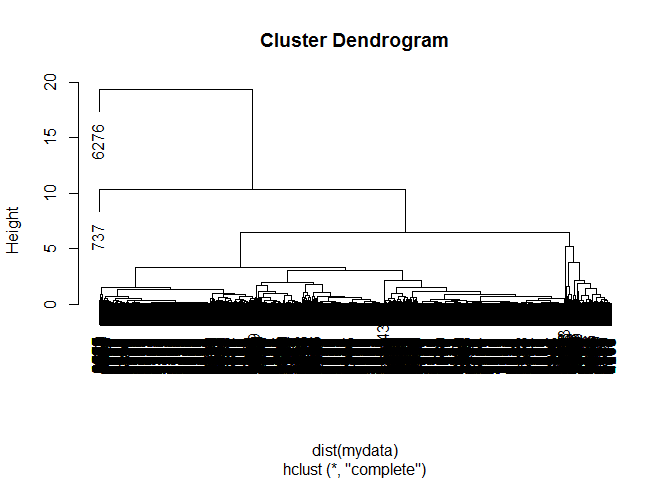

```r
mydata <- df[, 1:2]

set.seed(20)
clusters <- hclust(dist(mydata))  #default method = complete linkage
plot(clusters)
```

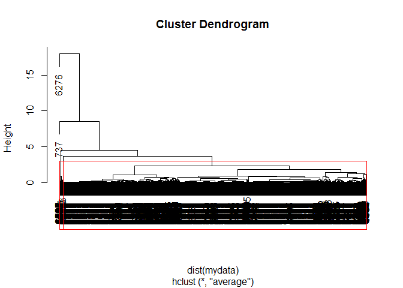

```r
clusters <- hclust(dist(mydata), method = "average")
plot(clusters)
groups <- cutree(clusters, k = 5)  # cut tree into 5 clusters
# draw dendogram with red borders around the 5 clusters
rect.hclust(clusters, k = 5, border = "red")
```